# Evolution of Cooperation (Section 2)

6 February 2017

## Roadmap

- Quick review of basic games
- Social preferences
- Evolutionary game theory

## Review of Basic Games

- Two strategies and two players. The players **simultaneously** decide which strategy to select.
- The **best response** is the strategy which produces the most favorable outcome for a player, *taking the other player's strategy as given*.
- A set of (pure) strategies \((A_1,A_2)\) is a **Nash Equilibrium** if player 1 is playing a best response against player 2, and player 2 is playing a best response against player 1!
- \(U_1(A_1,A_2) > U_1(B_1,A_2)\) **and** \(U_2(A_1,A_2) > U_2(A_1,B_2)\)
- In a NE, neither player has an incentive to switch strategies!

## Review of Basic Games

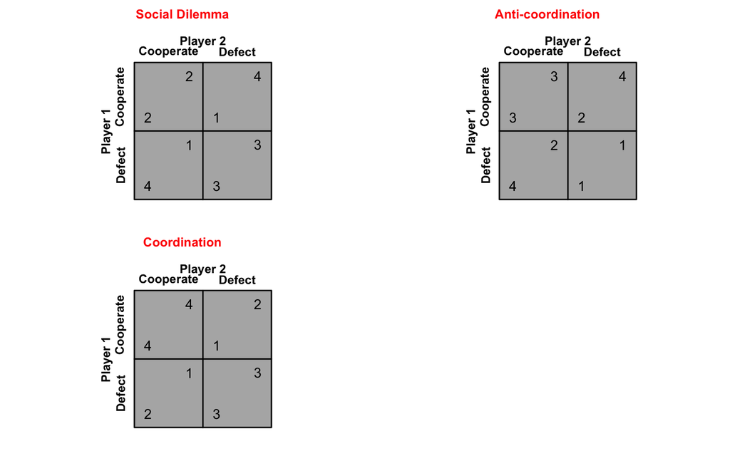

## Review of Basic Games

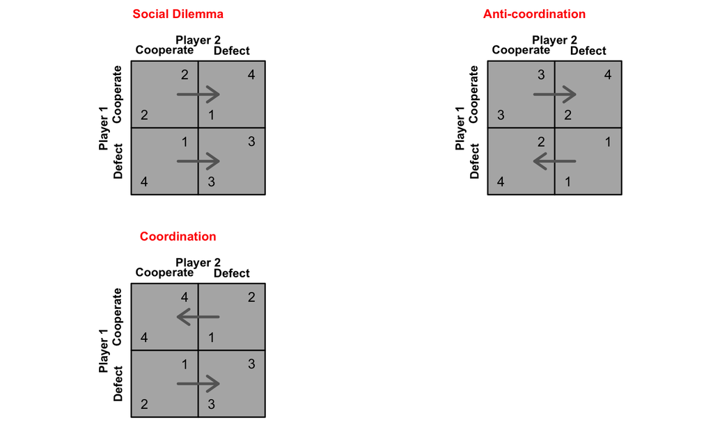

## Review of Basic Games

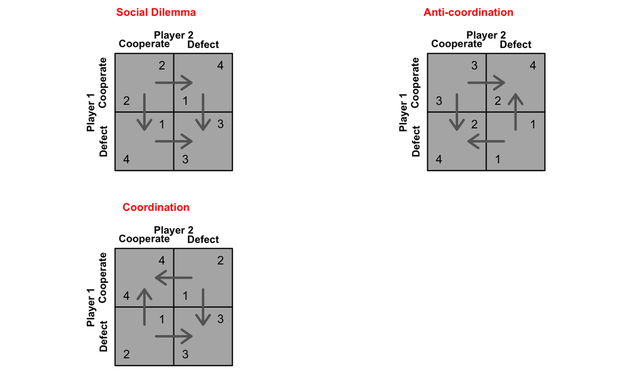

## Review of Basic Games

Nash equilibria: both players are playing their best responses to the other one. Once we get here, we are stuck!

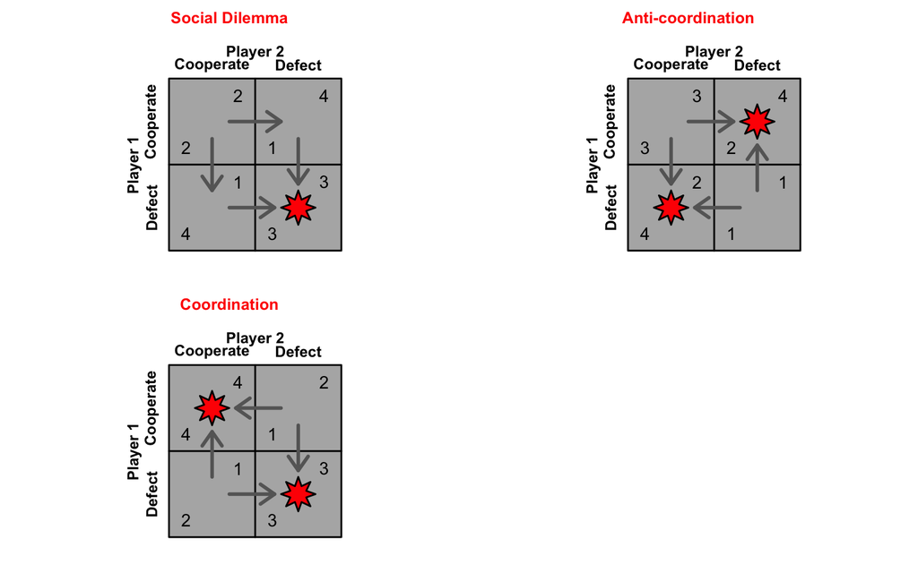

## Social Preferences

- "Homo-economicus": players are "selfish" and predicted behavior simply a function of individual payoffs.
- But even in one-shot prisoner's dilemmas, rate of cooperation is typically 40-60%.
- Why? If players have **social preferences**, behavior also depends on what happens to others and why these things happen.
- Can be "other-regarding"–my evaluation of some state depends on how you are doing.
- Can be "process-regarding"–my evaluation of some state depends on how it came about.
- Examples: altruism, fairness, reciprocity and inequity averson.

## Altruism

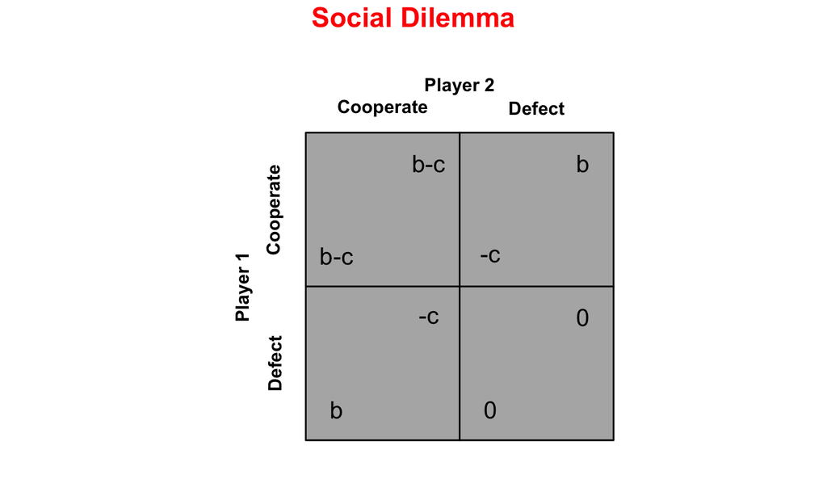

## Altruism

Let \(b=2\), \(c=1\), \(\kappa\in(0,1)\) "altruism" parameter.

|  | Selfish person | Altruistic person |
| --- | --- | --- |
| \(U_1(C,C)\) | \(b-c = 1\) | \(b-c+\kappa(b-c) = 1+\kappa\) |
| \(U_1(D,C)\) | \(b = 2\) | \(b-\kappa c = 2-\kappa\) |
| \(U_1(C,D)\) | \(-c = -1\) | \(-c + \kappa b = 2\kappa -1\) |
| \(U_1(D,D)\) | \(0\) | \(0\) |

Cooperative NE?

\[ 1+\kappa > 2-\kappa \implies \kappa > 1/2 \]

## Altruism

Suppose \(\kappa=3/4\) (high altruism):

|  | Selfish person | Altruistic person |
| --- | --- | --- |
| \(U_1(C,C)\) | \(b-c = 1\) | \(b-c+\kappa(b-c) = 1+\kappa=1.75\) |
| \(U_1(D,C)\) | \(b = 2\) | \(b-\kappa c = 2-\kappa=1.25\) |
| \(U_1(C,D)\) | \(-c = -1\) | \(-c + \kappa b = 2\kappa -1=0.5\) |
| \(U_1(D,D)\) | \(0\) | \(0\) |

## Altruism

Suppose \(\kappa=3/4\) (high altruism):

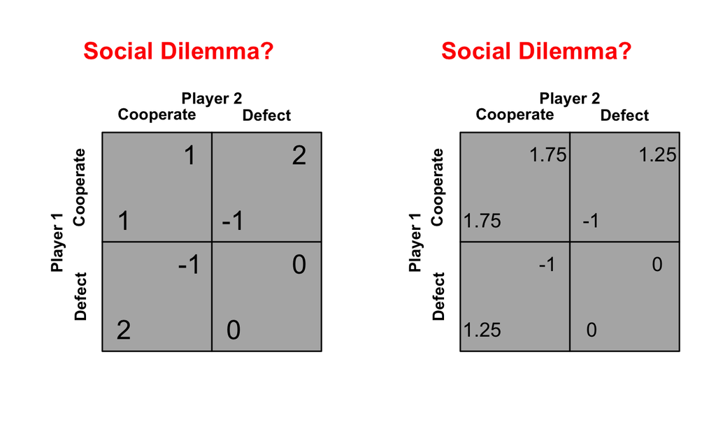

## Altruism

Suppose \(\kappa=3/4\) (high altruism):

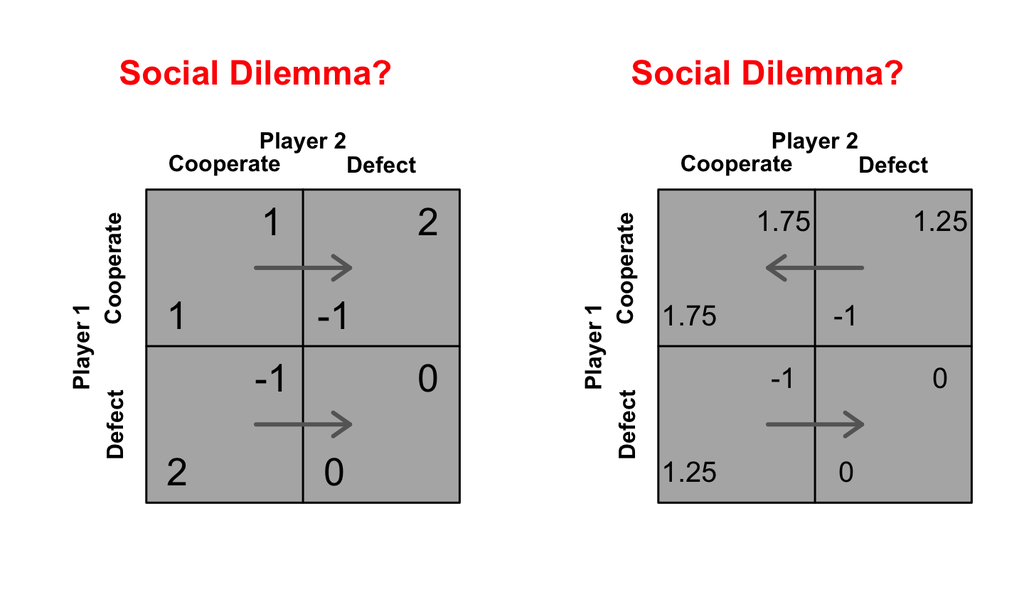

## Altruism

Suppose \(\kappa=3/4\) (high altruism):

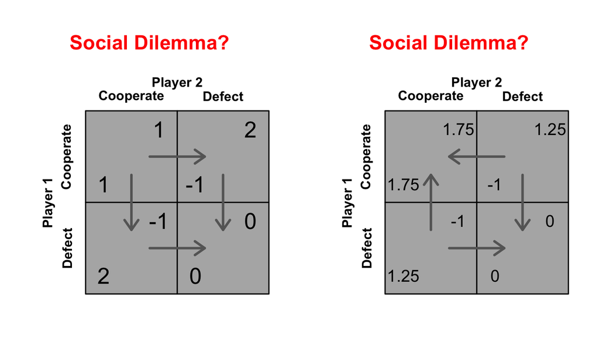

## Altruism

Suppose \(\kappa=3/4\) (high altruism):

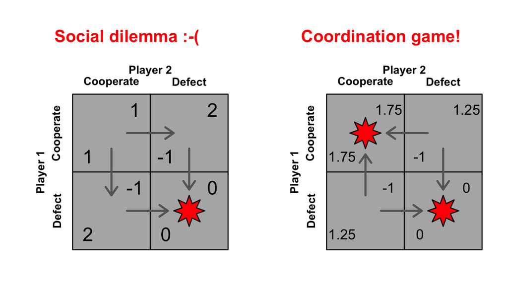

## Inequity aversion

P1's utility: \(U_1=\pi_1 - \delta_1\max(\pi_2-\pi_1,0)-\alpha_1\max(\pi_1-\pi_2,0)\)

\(\delta_1\): how much P1 dislikes disadvantageous (\(\pi_2-\pi_1>0\)) differences.

\(\alpha_1\in(0,1)\): how much P1 dislikes advantageous (\(\pi_1-\pi_2>0\)) differences.

If \(\alpha_1=1\) then P1 cares only about P2's payoffs if they fall short of her own.

If \(\delta_1>1\), P1 is very adverse to disadvantageous differences.

## Inequity aversion

Suppose \(\alpha\), \(\delta\) are the same for both players. Again consider social dilemma setup with \(c=1,b=2\).

|  | Selfish person | Inequity averse person |
| --- | --- | --- |
| \(U(C,C)\) | \(b-c = 1\) | \(b-c=1\) |
| \(U(D,C)\) | \(b = 2\) | \(b-\alpha[b-(-c)]= 2-3\alpha\) |
| \(U(C,D)\) | \(-c = -1\) | \(-c - \delta[b-(-c)] = -1-3\delta\) |
| \(U(D,D)\) | \(0\) | \(0\) |

Cooperative NE?

\[ 1> 2-3\alpha \implies \alpha > 1/3 \]

## Inequity aversion

Suppose \(\alpha = 3/4\), \(\delta = 2\):

|  | Selfish person | Inequity averse person |
| --- | --- | --- |
| \(U(C,C)\) | \(b-c = 1\) | \(b-c=1\) |
| \(U(D,C)\) | \(b = 2\) | \(b-\alpha[b-(-c)]= 2-3\alpha=-0.25\) |
| \(U(C,D)\) | \(-c = -1\) | \(-c - \delta[b-(-c)] = -1-3\delta=-7\) |
| \(U(D,D)\) | \(0\) | \(0\) |

## Inequity aversion

Suppose \(\alpha = 3/4\), \(\delta = 2\):

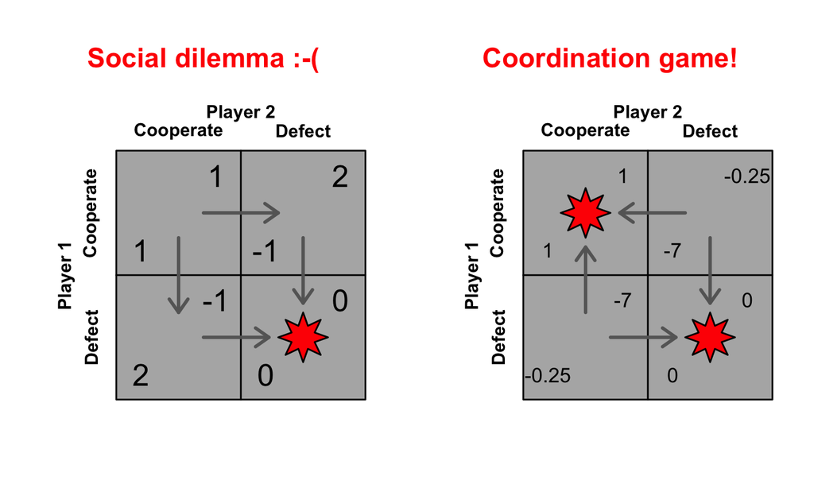

## Evolutionary game theory (Dominance)

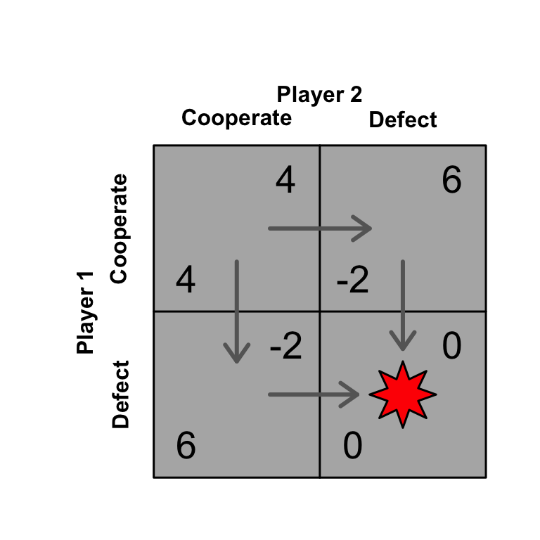

- Mutual defection is the NE. This is also the ESS.
- \(\pi_C = 4x-2(1-x) = 6x-2\), \(\pi_D = 6x+0(1-x)=6x\)
- At \(x=1/2\), \(\pi_C = 1 < \pi_D = 3\) so \(D\) is "risk dominant"